# 03-Network data in `R`

### Edge lists

Another useful form of representation for network data are the edge lists. They are just listings of the nodes that are actually connected. Edge lists are usually input as dataframes.

```r
# Load required package
library(networkD3)

# Create fake data
source <- c("A", "A", "A", "A",
            "B", "B", "C", "C", "D")
target <- c("B", "C", "D", "J",
            "E", "F", "G", "H", "I")

networkData <- data.frame(source, target)
networkData
```

```
##   source target
## 1      A      B
## 2      A      C
## 3      A      D
## 4      A      J
## 5      B      E
## 6      B      F
## 7      C      G
## 8      C      H
## 9      D      I
```

```r
# Plot
simpleNetwork(networkData)
```

[interactive chart not shown]

In addition, we have the option of using the `tidyverse` framework:

```r
# Load required package
library(tidyverse)
library(visNetwork)

# The edges can be specified as a data.frame or a list with edges informations.
edge_list <- tibble(from = c("A", "A", "A", "A",
                             "B", "B", "C", "C", "D"),
                    to = c("B", "C", "D", "J",
                           "E", "F", "G", "H", "I"),
                          value = 1)

node_list <- tibble(id = LETTERS[1:10], label = paste(LETTERS[1:10]))

node_list
```

```
## # A tibble: 10 × 2
##    id    label
##    <chr> <chr>
##  1 A     A
##  2 B     B
##  3 C     C
##  4 D     D
##  5 E     E
##  6 F     F
##  7 G     G
##  8 H     H
##  9 I     I
## 10 J     J
```

```r
edge_list
```

```
## # A tibble: 9 × 3
##   from  to    value
##   <chr> <chr> <dbl>
## 1 A     B         1
## 2 A     C         1
## 3 A     D         1
## 4 A     J         1
## 5 B     E         1
## 6 B     F         1
## 7 C     G         1
## 8 C     H         1
## 9 D     I         1
```

```r
visNetwork(node_list, edge_list, label= T)
```

[interactive chart not shown]

### Converting to edgelists

When starting with an adjacency matrix we can convert it to an edgelist with a matrix vectorization. The vectorization is simply a listing of each cell in the matrix, labelled with the combination of its row and column labels.

```r
# Vectorize the matrices.
source("./code/functions/vectorize.R")

# Input the dataset, as adjacency matrix
pm.disp<- read.table("./data/pmah_disp.txt",
                     na="NA", sep="\t", dec=".", header= TRUE)

pm.disp.mat<- as.matrix(pm.disp[,2:22])
row.names(pm.disp.mat)<- pm.disp$X
head(pm.disp.mat)
```

```
##      Columba.palumbus Garrulus.glandarius Turdus.merula Phoenicurus.ochruros
## 1933                0                   4             6                   20
## 1931                0                   2             1                   64
## 1932                0                   2             3                   33
## 1934                0                   1             0                    8
##      Erithacus.rubecula Parus.ater Fringilla.coelebs Sylvia.conspicillata
## 1933                  5         20                48                    2
## 1931                  3         10                51                    2
## 1932                  0         21                34                    0
## 1934                  0          8                 6                    0
##      Sylvia.atricapilla Turdus.viscivorus Sylvia.communis Sylvia.melanocephala
## 1933                  7                18               7                    2
## 1931                  2                 2              11                    0
## 1932                  0                 1               2                    1
## 1934                  0                 0               0                    0
```

[output cut: 16 more lines]

```r
# Edge lists
pru.disp.el<- vectorize(pm.disp.mat) # Edge list-dispersers.
colnames(pru.disp.el)<- c("plant", "frugivore", "w")
head(pru.disp.el)
```

```
##   plant            frugivore  w
## 1  1933     Columba.palumbus  0
## 2  1933  Garrulus.glandarius  4
## 3  1933        Turdus.merula  6
## 4  1933 Phoenicurus.ochruros 20
## 5  1933   Erithacus.rubecula  5
## 6  1933           Parus.ater 20
```

```r
# Write edge lists
# NOT RUN!
write.table(pru.disp.el, file = "./data/pru.disp.el.txt", sep = "\t", col.names = T)
```

## Network data as R objetcs

### Formats

#### `network`

##### Simpe bipartite graph

The `network` function constructs a network class object from a matrix representation. `summary.network` provides basic information about the network object. Finally, `as.network` tries to coerce its argument to a network, using the `as.network.matrix` functions if `x` is a matrix. If the argument is already a network object, it is returned as-is and all other arguments are ignored.

```r
# Load package
library(ggplot2)
#---------------------------------------------------------------------------
# A weighted adjacency matrix. Rows are animal species; columns
# are plant species.
bip= data.frame(P1= c(1, 12, 6, 0),
                P2= c(1, 0, 4, 0),
                P3= c(1, 7, 3, 12),
     row.names= letters[1:4])
#---------------------------------------------------------------------------
#---------------------------------------------------------------------------
# Function to initialize a bipartite web for library network (type network),
# starting from its adjacency matrix.
# Usually we assume animal species are rows, plant species are columns.
#---------------------------------------------------------------------------
bip_init_network <- function (mymat, mode1="P", mode2="A") {
    require(network)
    require(ggnet)
    if(!is.matrix(mymat)) mymat <- as.matrix(mymat)
    p<- dim(mymat)[1]    # Plants are rows
    a<- dim(mymat)[2]    # Animals are columns
    net<- network::network(mymat,
                  matrix.type = "bipartite",
                  ignore.eval = FALSE,
                  names.eval = "weights")
    net
    network::set.vertex.attribute(net,"mode",c(rep(mode1,p), rep(mode2,a)))
}
```

#### `igraph`

Igraph graphs have a class `igraph`. They are printed to the screen in a special format. To create graphs from field data, `graph_from_edgelist`, `graph_from_data_frame` and `graph_from_adjacency_matrix` are probably the best choices.

When using function `graph.incidence`, it yields a bipartite igraph-type graph. In other words, an igraph graph that has a vertex attribute type.

```r
# Initialize networks for igraph.
# Exporting web as edge list and its names.
library(igraph)
mymat<- netmat1
web2edges(mymat,"mat2.ig",
          out.files=c("edges", "names", "groups")[1:2],
          return=FALSE, verbose=FALSE)
edges<-read.table("mat2.ig.pairs",header=F,sep="\t")

# Creating the graph from a weighted incidence data with names:
mymat.ig<-graph.incidence(netmat1,
                          directed=F,
                          weighted=T,
                          add.names=NULL)
plot(mymat.ig)

# Quick graph creation with graph formula
motif1 <- graph.formula(Gallotia--Isoplexis, Phylloscopus--Isoplexis, Herbivore--Isoplexis)
```

```r
g <- graph.bipartite(rep(0:1,length=10), c(1:10))
print(g, v=TRUE)
plot(g)
```

Let’s do a quick example of input and analysis of network data in `R`.

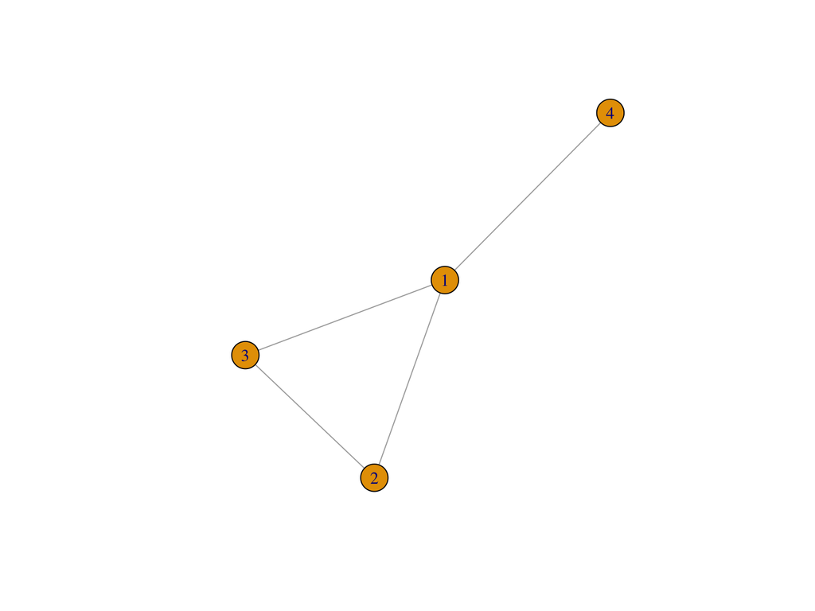

```r
#-----------------------------------------------------------------------
# We use the tools in igraph package.
#-----------------------------------------------------------------------
library(igraph)
# Specify the adjacency matrix
A <- matrix(c(0,1,1,1,1,0,1,0,1,1,0,0,1,0,0,0 ), 4, 4, byrow= TRUE)
rownames(A) <- c("A","B","C","D")
     # convert adjacency matrix to an igraph object
G <- graph.adjacency(A, mode= c("undirected"))
     # calculate betweeness & eigenvector centrality
cent <- data.frame(bet=betweenness(G), eig=evcent(G)$vector)
     # calculate residuals
res <- as.vector(lm(eig~bet, data=cent)$residuals)
     # add to centrality data set
cent <- transform(cent, res=res)
rownames(cent)<- c("A","B","C","D")
     # save in project folder
write.csv(cent,"r_keyactorcentrality.csv")
     # network visualization
plot(G, layout = layout.fruchterman.reingold)
```

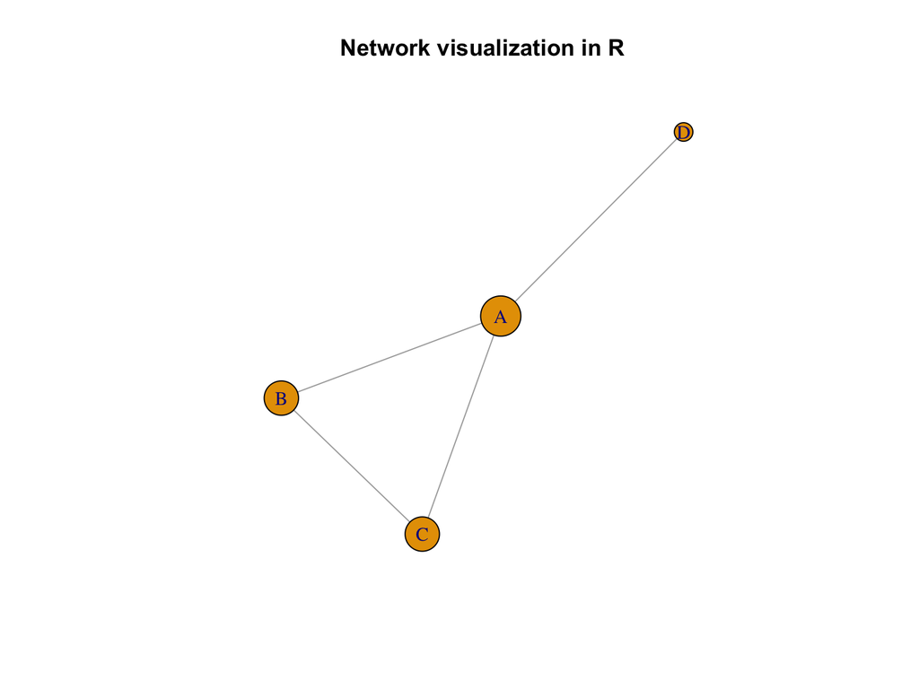

```r
     # create vertex names and scale by centrality
plot(G, layout = layout.fruchterman.reingold,
     vertex.size = 20*evcent(G)$vector,
     vertex.label = rownames(cent),
     main = 'Network visualization in R')
```

### Input from web repositories (e.g., GitHub)

Data can be imported directly from, e.g., a GitHub repository, giben that the repsitory has GitHub pages enabled, for example in a `/docs`folder:

```r
sdw01 <-read.csv("https://raw.githubusercontent.com/pedroj/plant-frug_networks_ES/master/data/sdw01/sdw01_adj_vis.csv?token=GHSAT0AAAAAABQLPTGGOKYWHNSYKCD2QUPWYQC3ASQ",
                 header= F, row.names=1, comment= "#", dec=".", na.strings="NA")

glimpse(sdw01)
```

```
## Rows: 26
## Columns: 36
## $ V2  <chr> "Columba.palumbus", "0", "0", "0", "0", "3", "0", "0", "2", "0", "…
## $ V3  <chr> "Corvus.corax", "0", "0", "0", "0", "2", "0", "0", "0", "0", "0", …
## $ V4  <chr> "Corvus.corone", "0", "0", "1", "0", "4", "0", "0", "0", "0", "3",…
## $ V5  <chr> "Dendrocopos.major", "0", "0", "0", "0", "0", "0", "0", "0", "0", …
## $ V6  <chr> "Erithacus.rubecula", "2", "1", "25", "1", "36", "1", "4", "2", "0…
## $ V7  <chr> "Ficedula.hypoleuca", "0", "0", "0", "0", "0", "0", "0", "0", "0",…
## $ V8  <chr> "Phoenicurus.ochruros", "1", "0", "85", "0", "49", "0", "1", "2", …
## $ V9  <chr> "Phoenicurus.phoenicurus", "0", "0", "4", "0", "0", "0", "0", "0",…
## $ V10 <chr> "Pica.pica", "0", "0", "2", "0", "6", "0", "0", "0", "0", "0", "0"…
## $ V11 <chr> "Sylvia.atricapilla", "0", "0", "11", "0", "12", "10", "56", "0", …
## $ V12 <chr> "Sylvia.borin", "0", "0", "3", "0", "0", "0", "0", "0", "0", "0", …
## $ V13 <chr> "Sylvia.cantillans", "0", "0", "10", "0", "4", "0", "0", "1", "0",…
## $ V14 <chr> "Sylvia.communis", "0", "0", "0", "0", "0", "0", "0", "0", "0", "0…
```

[output cut: 23 more lines]

## Writing and exporting network data

The `write.graph()` function exports a graph object in various formats readable by other programs. There is no explicit option for a UCINET data type, but you can export the graph as a Pajek object by setting the `format` parameter to `pajek`. Note that the file will appear in whichever directory is set as the default in R’s preferences, unless you previously changed this via `setwd()`.

```r
write.graph(mymat, file='mymat.dl', format="pajek")
```

For a more general file type (e.g., importable to Excel), use the `edgelist` format. Note that neither of these will write the attributes; only the links are maintained.

```r
write.graph(mymat, file='mymat.txt', format="edgelist")
```

## References

1.

Jordano P. 2016. Sampling networks of ecological interactions. *Functional Ecology*. 30:1883–93

Licensing Creative Commons License

Licensed under a Creative Commons Attribution-ShareAlike 4.0 International License.  
2018 - Pedro Jordano